# Retinal Blood Vessel Segmentation

Retinal fundus image is the image of the back of the eye taken by fundus camera. It can reveal eye defects resulted from diseases like hypertension or diabetis. An automated system to diagnosis retinopathy carries great importance as fundus image can be hars diagnose with the naked eye, for example to detect toruosity or vessel wall thickeing. For automated detection the first step is to seperate the vasculature from the rest of the eye. Here we will try to investigate the effect of different image enhencement techniques in classifying the fundus image pixel as vesel or non vessel.

The project is divided into following segments

1. Dataset generation
2. Image enhecement
3. Classification

# 1. Dataset Generation

We use DRIVE dataset which is the most used in the literature. In DRIVE database there are 20 train images and 20 test images along with their mask image and ground trith. Mask image seperates the FOV (field of view) from the rest of the image. The ground truh is produced by manual segmentation.

We take out patches with size 27 * 27 from the images and label them according the centre pixel as positive or negative. From each image, both train and test set, 1000 patches are taken. So there are 20000 train patches and 20000 test patches.

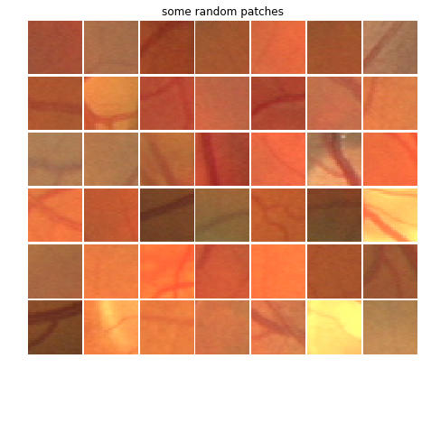

```python
%matplotlib inline
import numpy as np
from PIL import Image
import matplotlib.pyplot as plt

## load the data
data = np.load('E:\\library of EEE\\4-2\\eee 426\\data\\MSCprojectDataBase\\simpleClassifierDataBase\\DRIVEtrainData.npy')
data = data.astype('uint8')

## plotting the patches
fig = plt.figure(figsize = (6, 6))
fig.subplots_adjust(left = 0, right = 1, bottom = 0, top = 1, hspace = 0.05, wspace = 0.005)
plt.title('some random patches')
plt.axis('off')
l = np.random.randint(0, 20000, size = 42)
for i, j in enumerate(l):
	ax = fig.add_subplot(7, 7, i + 1)
	ax.imshow(data[j], cmap = 'binary')
	plt.axis('off')
plt.show()
```

To check whether patches are taken from all over the image evenly we check the scatter plot

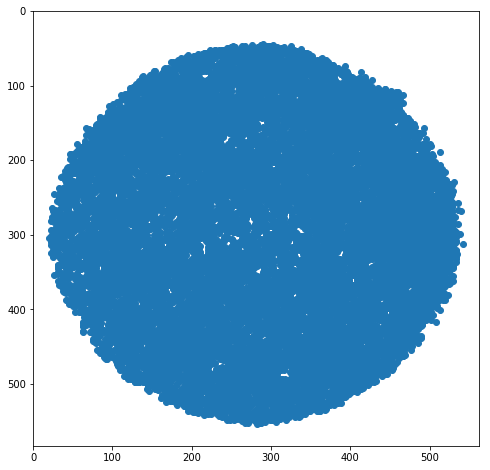

```python
## load patch location
dataLoc = np.load('E:\\library of EEE\\4-2\\eee 426\\data\\MSCprojectDataBase\\simpleClassifierDataBase\\DRIVEtrainDataLcation.npy')

## plotting the data location to see the randomness
fig = plt.figure(figsize = (8, 8))
plt.scatter(dataLoc[:,1], dataLoc[:,0])
plt.axis([0, 563, 583, 0])
plt.show()
```

# 2. Image Enhancement

We apply different image enhencement techniques on the image patches. Here we consider six different conditions

1. gaussian filtering
2. median filtering
3. laplacian filtering
4. sobel filtering
5. histogram equalization and
6. only green channel image

[figure not shown]

```python
import cv2
import numpy as np
import matplotlib.pyplot as plt
from sys import exit

data = np.load('E:\\library of EEE\\4-2\\eee 426\\data\\MSCprojectDataBase\\simpleClassifierDataBase\\DRIVEtestData.npy')
data = data.astype('uint8')

## to work with opencv the channel 0 and 2 must be interchanged
## because opencv read image as BGR and our image is in RGB order
def swapchannels(data):
	temp = np.ones(data[0].shape)

	for i in range(20000):
		temp[:, :, 0] = data[i, :, :, 2]
		data[i, :, :, 2] = data[i, :, :, 0]
		data[i, :, :, 0] = temp[:, :, 0]

swapchannels(data)

## laplacian filter
lapFilter = np.ones((20000, 27, 27, 3))
for i in range(20000):
    lapFilter[i] = cv2.Laplacian(data[i], -1)
swapchannels(lapFilter)

## plotting the patches
fig = plt.figure(figsize = (6, 6))
fig.subplots_adjust(left = 0, right = 1, bottom = 0, top = 1, hspace = 0.05, wspace = 0.005)
plt.title('some randome patches after using laplacian filter')
plt.axis('off')
l = np.random.randint(0, 20000, size = 42)
for i, j in enumerate(l):
	ax = fig.add_subplot(7, 7, i + 1)
	ax.imshow(lapFilter[j], cmap = 'binary')
	plt.axis('off')
plt.show()
```

# 3. Classification

```python
from keras.models import Sequential
from keras.layers import Dense, Activation
from keras.utils import np_utils
from keras import regularizers

## load the data as numpy array
data_train = np.load('E:\\library of EEE\\4-2\\eee 426\\data\\MSCprojectDataBase\\simpleClassifierDataBase\\DRIVEtrainData.npy')
label_train = np.load('E:\\library of EEE\\4-2\\eee 426\\data\\MSCprojectDataBase\\simpleClassifierDataBase\\DRIVEtrainDataLabel.npy')

data_test = np.load('E:\\library of EEE\\4-2\\eee 426\\data\\MSCprojectDataBase\\simpleClassifierDataBase\\DRIVEtestData.npy')
label_test = np.load('E:\\library of EEE\\4-2\\eee 426\\data\\MSCprojectDataBase\\simpleClassifierDataBase\\DRIVEtestDataLabel.npy')

## reshaping and normalizing the data
## (27 * 27 * 3 = 2187) except green channel and clahe image (27 * 27 = 729)
input_dim = 2187
x_train = data_train.reshape(20000, input_dim).astype('float')
x_test = data_test.reshape(20000, input_dim).astype('float')

## normalizing the data
x_train /= 255
x_test /= 255

## modifying the label as catagorical
label_train = (label_train / 255).astype('int')
y_train = np_utils.to_categorical(label_train, 2)

label_test = (label_test / 255).astype('int')
y_test = np_utils.to_categorical(label_test, 2)

## defining model
model = Sequential()
model.add(Dense(2, input_dim = input_dim, activation = 'softmax', kernel_regularizer = regularizers.l2(0.0001)))

## compiling the model
model.compile(optimizer = 'adam', loss='categorical_crossentropy', metrics=['accuracy'])

## fitting the data
batch_size = 128
epoch = 200
history = model.fit(x_train, y_train, batch_size = batch_size, nb_epoch = epoch, verbose = 0, shuffle = False, validation_data = (x_test, y_test))

## score the model
score = model.evaluate(x_test, y_test, verbose = 0)
print(model.metrics_names, score)
```

```
['loss', 'acc'] [0.43866405463218688, 0.82574999999999998]
```

# Result

By tweaking with the model a bit (using adam optimizer instead of sgd and decreasing the regularization constant) a fairly good accuracy can be achieved from the untouched (not gone through enhencement) data for 200 epoch. Interestingly though, the enhencement images provide poorer result. The accuray achieved by these data are shown in bar plot -

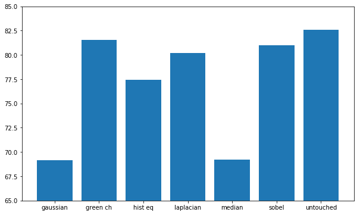

```python
dataset = ['untouched', 'gaussian', 'median', 'laplacian', 'sobel', 'hist eq', 'green ch']
acc = [82.57, 69.16, 69.24, 80.21, 80.97, 77.45, 81.53]

fig = plt.figure(figsize = (10, 6))
plt.bar(dataset, acc)
plt.ylim([65, 85])
plt.show()
```

For full code and data see the project [repository](https://github.com/nakib103/Retinal-Blood-Vessel-Segmentation)